# hw3

Mikołaj Zięcina

2023-03-29

## Praca domowa 3

Przygotowałem ramkę danych zawierającą informację na temat tego, ile pieniędzy na transfery wydały kluby piłkarskie grające w angielskiej Premier League korzystając z danych ze strony “www.transfermarkt.com” oraz dwa wykresy prezentujące te dane, stacked barplot oraz gruped barplot. Dane są podzielone na sezony (3 ostatnie sezony) oraz na letnie i zimowe okienko transferowe. Eksperyment polega na tym, że osoba odpowiada na pytanie, jaka kwota mniej więcej na każdym wykresie jest przedstawiona.

```r
library(ggplot2)
library(dplyr)
library(scales)
library(readxl)
library(patchwork)
```

```r
df <- data.frame(sezon = c('22/23', '22/23', '21/22', '21/22', '20/21', '20/21'),
                  okienko = c('lato', 'zima', 'lato', 'zima', 'lato', 'zima'),
                  kwota = c(2246699636, 829857000, 1339385000, 345480800,
                            1469909000, 89642000))
```

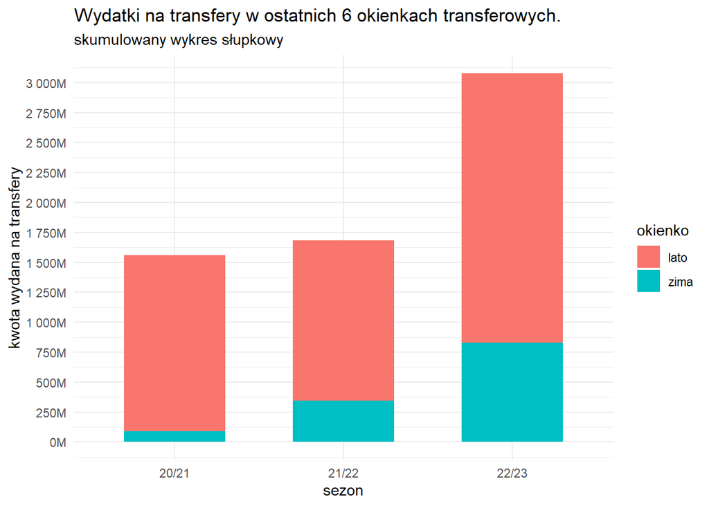

```r
plot1 <- df %>%
  ggplot(aes(x = sezon, y = kwota, fill = okienko)) +
  geom_bar(position="stack", stat="identity", width = 0.6)+
  scale_y_continuous(n.breaks = 15, labels = label_number(suffix = 'M', scale = 1e-6))+
  labs(title = "Wydatki na transfery w ostatnich 6 okienkach transferowych.",
     subtitle = 'skumulowany wykres słupkowy', y = 'kwota wydana na transfery')+
  theme_minimal()
plot1
```

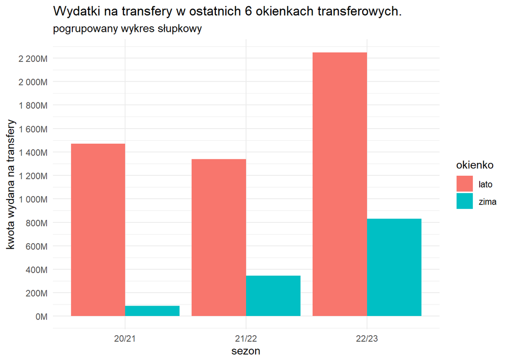

```r
plot2 <- df %>%
  ggplot(aes(x = sezon, y = kwota, fill = okienko)) +
  geom_bar(position="dodge", stat="identity")+
  scale_y_continuous(n.breaks = 15, labels = label_number(suffix = 'M', scale = 1e-6))+
  labs(title = "Wydatki na transfery w ostatnich 6 okienkach transferowych.",
       subtitle = 'pogrupowany wykres słupkowy', y = 'kwota wydana na transfery')+
  theme_minimal()
plot2
```

Moim wstępnym podejrzeniem było to, że będą problemy z odczytaniem wartości dla letnich okienek transferowych dla wykresu stacked barplot wynikające z faktu, że wykres nie zaczyna się w zerze i trzeba odjąć wartość zimowego okienka.

```r
wyniki <- read_excel('wyniki.xlsx')
wyniki_zima <- wyniki %>%
  filter(okienko == 'zima') %>%
  select(sezon, kwota_z_p1, kwota_z_p2) %>%
  rename(obserwacja_z_wykresu1 = kwota_z_p1, obserwacja_z_wykresu2 = kwota_z_p2) %>%
  mutate(roznica = obserwacja_z_wykresu1 - obserwacja_z_wykresu2)
head(wyniki_zima)
```

```
## # A tibble: 6 x 4
##   sezon obserwacja_z_wykresu1 obserwacja_z_wykresu2 roznica
##   <chr>                 <dbl>                 <dbl>   <dbl>
## 1 20/21                    85                    85       0
## 2 21/22                   360                   360       0
## 3 22/23                   835                   835       0
## 4 20/21                   100                   100       0
## 5 21/22                   350                   350       0
## 6 22/23                   850                   850       0
```

```r
wyniki_zima$roznica
```

```
##  [1] 0 0 0 0 0 0 0 0 0 0 0 0 0 0 0 0 0 0 0 0 0 0 0 0 0 0 0 0 0 0 0 0 0 0 0 0 0 0
## [39] 0 0 0 0 0 0 0
```

Jak możemy zaobserować róznica w odczytach dla zimowych okienek transferowych jest zerowa. Wynika to prawdopodobnie z faktu, że odczytując z drugiego wykresu osoba miała możliwość zerknąć na poprzednie odpowiedzi. Z tego powodu zajmiemy się analizowaniem odpowiedzi jedynie dla letnich okienek transferowych.

```r
wyniki_lato <- wyniki %>%
  filter(okienko == 'lato') %>%
  rename(obserwacja_z_wykresu1 = kwota_z_p1, obserwacja_z_wykresu2 = kwota_z_p2) %>%
  mutate(wb_roznicy_obu = abs(obserwacja_z_wykresu1 - obserwacja_z_wykresu2),
         kwota = kwota/10^6) %>%
  mutate(wb_roznicy_odp1 = abs(obserwacja_z_wykresu1 - kwota),
         wb_roznicy_odp2 = abs(obserwacja_z_wykresu2 - kwota))
```

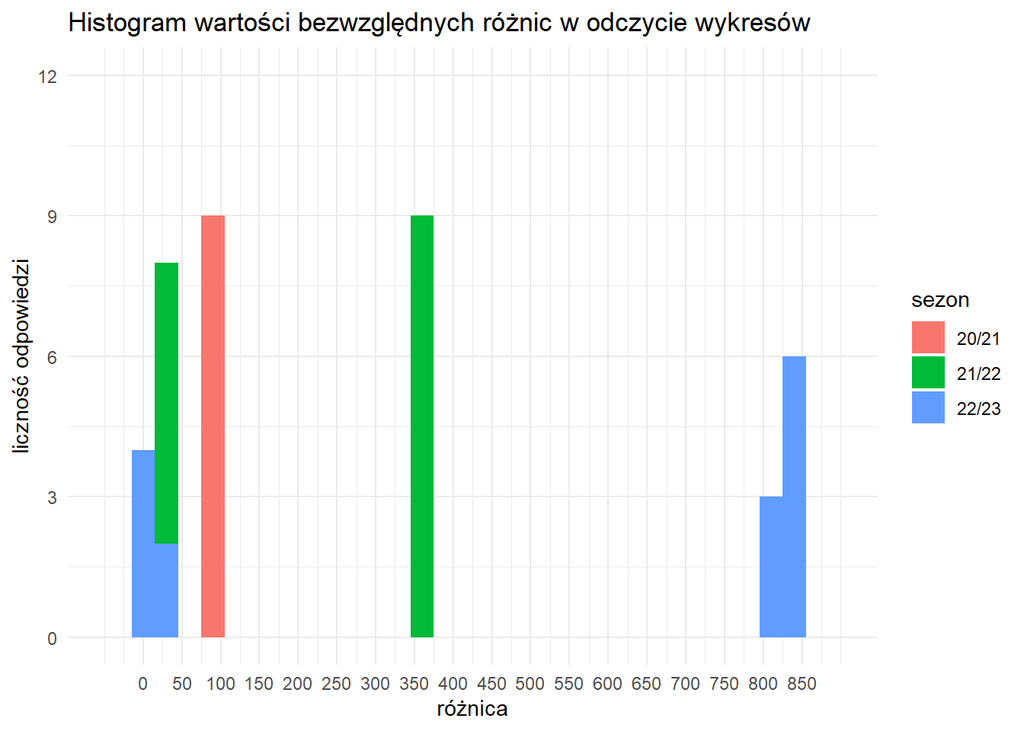

```r
ggplot(wyniki_lato, aes(x = wb_roznicy_obu, fill = sezon))+
  geom_histogram(binwidth = 30)+
  scale_x_continuous(limits = c(-50, 900), breaks = seq(0, 850, by = 50))+
  scale_y_continuous(limits = c(0, 12), breaks = seq(0, 12, by = 3))+
  labs(title = 'Histogram wartości bezwzględnych różnic w odczycie wykresów',
       x = 'różnica', y = 'liczność odpowiedzi')+
  theme_minimal()
```

Z tego wykresu możemy zaobserwować, że spośród wszystkich odpowiedzi wyłaniają nam się dwie grupy, gdzie jedne mają dużą różnicę w obserwacjach a drugie znacznie mniejszą. Przyjrzyjmy się najpierw tym z dużą różnicą.

```r
x <- wyniki_lato %>%
  filter(wb_roznicy_obu > 50) %>%
  select(osoba) %>%
  unique()
wektor_x <- x$osoba
wektor_x
```

```
## [1]  1  3  4  6  8  9 11 13 14
```

```r
wyniki_zima <- wyniki %>%
  filter(okienko == 'zima')

wyniki %>%
  filter(osoba %in% wektor_x) %>%
  filter(okienko == 'lato') %>%
  inner_join(wyniki_zima, by = c('sezon', 'osoba')) %>%
  mutate(poprawna_kwota = kwota_z_p1.x - kwota_z_p1.y) %>%
  select(poprawna_kwota, kwota_z_p2 = kwota_z_p2.x) %>%
  mutate(roznica = poprawna_kwota - kwota_z_p2)
```

```
## # A tibble: 27 x 3
##    poprawna_kwota kwota_z_p2 roznica
##             <dbl>      <dbl>   <dbl>
##  1           1475       1480      -5
##  2           1330       1330       0
##  3           2245       2245       0
##  4           1470       1470       0
##  5           1340       1340       0
##  6           2250       2250       0
##  7           1475       1475       0
##  8           1350       1340      10
##  9           2225       2250     -25
## 10           1475       1480      -5
## # ... with 17 more rows
```

Jeśli dla tej grupy odpowiedzi policzymy sobie różnicę w odczycie letniego i zimowego okienka w poszczególnych sezonach z wykresu skumulowanego i porównamy z obserwacjami letnich okienek z wykresu pogrupowanego, to różnica ta robi się niewielka. Sugeruje nam to, że część (nawet większość) osób, które wykonały eksperyment pomyślało, że na wykresie skumulowanych słupki letnich okienek zaczynają się w 0 i znajdują się za słupkami okienek zimowych. Jest to poważny probelem w odczytaniu wykresu, który dla tych osób niesie obserwacje mocno odbiegające od rzeczywistości.

Teraz przyjrzyjmy się grupie odpowiedzi z mniejszym błędem.

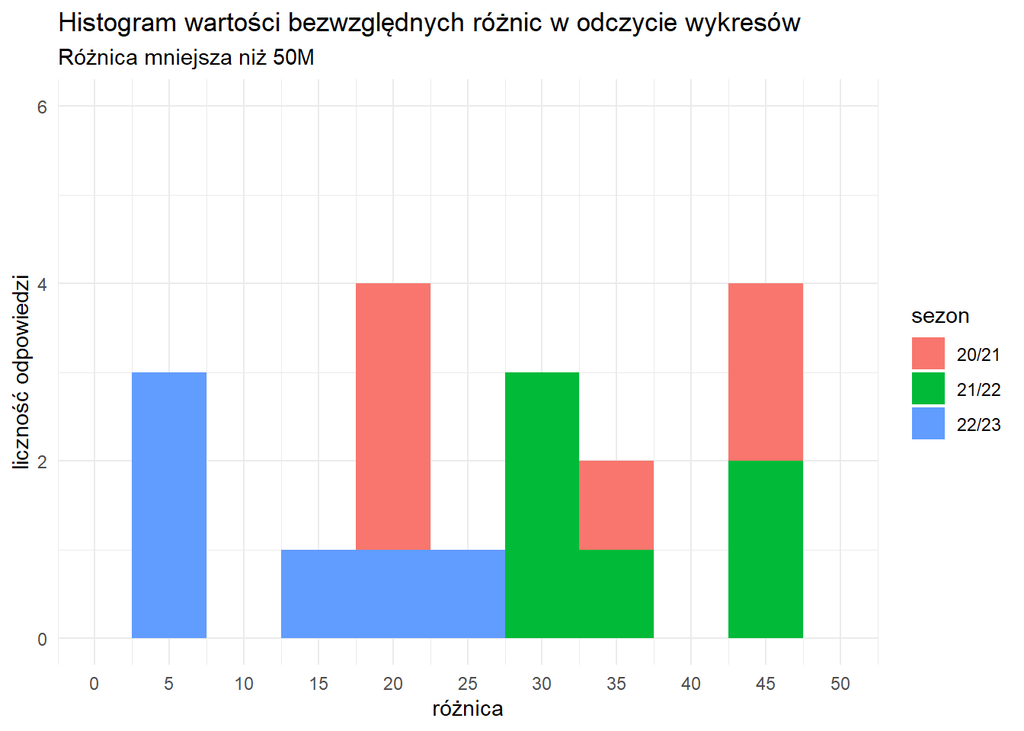

```r
wyniki_lato %>%
  filter(wb_roznicy_obu <= 50) %>%
  ggplot(aes(x = wb_roznicy_obu, fill = sezon))+
  geom_histogram(binwidth = 5)+
  scale_x_continuous(limits = c(0, 50), breaks = seq(0, 850, by = 5))+
  scale_y_continuous(limits = c(0, 6), breaks = seq(0, 12, by = 2))+
  labs(title = 'Histogram wartości bezwzględnych różnic w odczycie wykresów', x = 'różnica',
       y = 'liczność odpowiedzi', subtitle = 'Różnica mniejsza niż 50M')+
  theme_minimal()
```

Widzimy, że w pozostałych odpowiedziach te różnice nie są już tak duże, ale nadal dosyć znaczące. Najpierw upewnijmy się, który wykres został odczytany lepiej.

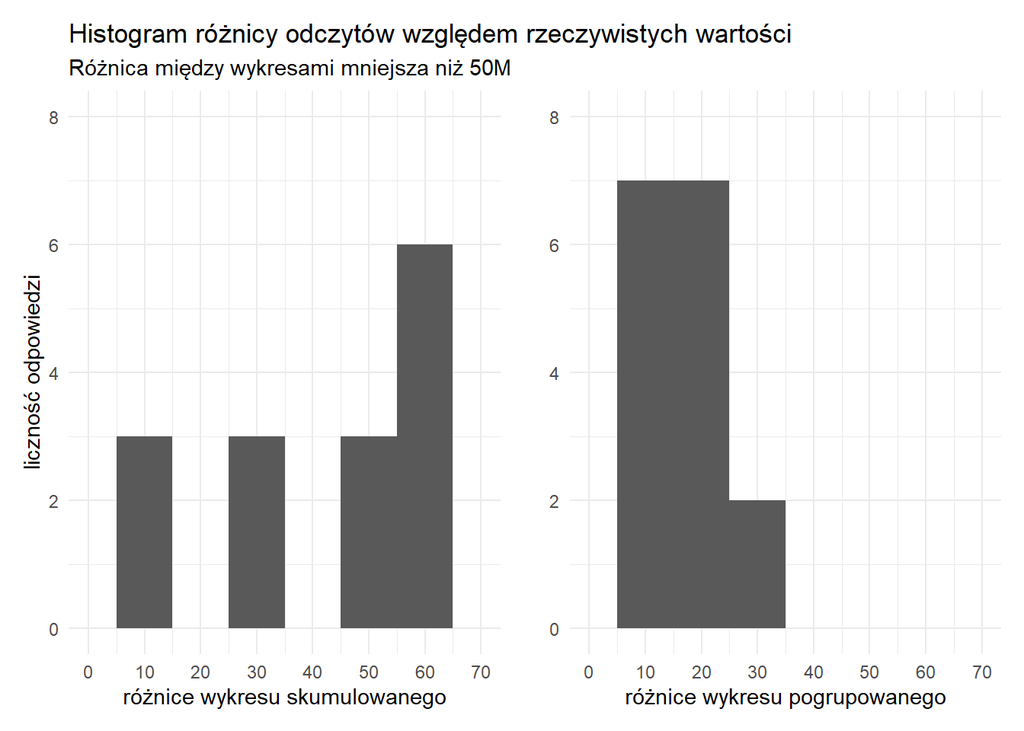

```r
p1 <- wyniki_lato %>%
  filter(wb_roznicy_obu <= 50) %>%
  ggplot(aes(x = wb_roznicy_odp1))+
  geom_histogram(binwidth = 10)+
  scale_x_continuous(limits = c(0, 70), breaks = seq(0, 850, by = 10))+
  scale_y_continuous(limits = c(0, 8), breaks = seq(0, 12, by = 2))+
  theme_minimal()+
  labs(title = 'Histogram różnicy odczytów względem rzeczywistych wartości', subtitle = 'Różnica między wykresami mniejsza niż 50M', x = 'różnice wykresu skumulowanego', y = 'liczność odpowiedzi')

p2 <- wyniki_lato %>%
  filter(wb_roznicy_obu <= 50) %>%
  ggplot(aes(x = wb_roznicy_odp2))+
  geom_histogram(binwidth = 10)+
  scale_x_continuous(limits = c(0, 70), breaks = seq(0, 850, by = 10))+
  scale_y_continuous(limits = c(0, 8), breaks = seq(0, 12, by = 2))+
  theme_minimal()+
  labs(x = 'różnice wykresu pogrupowanego', y = '')

p1 + p2
```

Jak widzimy odczyty z wykresu skumulowanego bardziej odbiegają od rzeczywistych wartości niż odczyty z wykresu pogrupowanego. Oznacza to, że potwierdziły się przewidywania, że ciężej osobom, a przynajmniej większości, odczytać wartości z wykresu skumulowanego. Ciekawą obserwacją jest to, że największą liczbą stanowią jednak osoby, które błędnie założyły, że słupki na górze, czyli przedstawiające kwoty wydane na letnich okienkach transferowych nie zaczynały się tam, gdzie się zaczynały tylko w 0 i znajdowały się za słupkami zimowych okienek. Wybór wykresu słupkowego pogrupowanego jest zdecydowanie lepszym wyborem.